# Assignment01_Part2_solution

## Deep Neural Networks (DNN)

**We are going to work with the `FashionMNIST` dataset for `image recognition task`. It has the exact same format as MNIST (70,000 grayscale images of 28 × 28 pixels each, with 10 classes), but the images represent fashion items rather than handwritten digits, so each class is more diverse, and the problem turns out to be significantly more challenging than MNIST.**

#### Load the Fashion MNIST using Keras datasets

We first use keras incoporated in TensorFlow 2.x for loading the training and testing sets.

```python
import tensorflow as tf
from tensorflow import keras
```

We first use keras datasets in TF 2.x to load Fashion MNIST dataset.

```python
fashion_mnist = keras.datasets.fashion_mnist
(X_train_full_img, y_train_full), (X_test_img, y_test) = fashion_mnist.load_data()
#Loading the dataset into training and testing form
```

The shape of X_train_full_img is $(60000, 28, 28 )$ and that of X_test_img is $(10000, 28, 28)$. We next convert them to matrices of vectors and store in X_train_full and X_test.

```python
num_train = X_train_full_img.shape[0]
num_test = X_test_img.shape[0]

#Resetting the shape of the dataset according to the file
X_train_full = X_train_full_img.reshape(num_train,-1)
X_test = X_test_img.reshape(num_test,-1)

print(X_train_full.shape, y_train_full.shape)    #(60000, 784) (60000,)
print(X_test.shape, y_test.shape)                #(10000, 784) (10000,)
```

```
(60000, 784) (60000,)
(10000, 784) (10000,)
```

#### Preprocess the dataset and split into training, validation, and testing datasets

You need to write the code to address the following requirements:

- Use $10 \%$ of X_train_full for validation and the rest of X_train_full for training. This splits X_train_full and y_train_full into X_train, y_train ($90 \%$) and X_valid, y_valid ($10 \%$).
- Finally, scale the piels of X_train, X_valid, and X_test to $[0,1]$) (i.e., $X = X/255.0$).

```python
import math
N = X_train_full.shape[0]
i = math.floor(0.9*N)

#Splitting the dataset according to the index or row number of the dataset with 90% allocated for training and 10% for.......
#validating, while other 10% is already given for testing
#Converting the pixel array data into scaled form

X_train, y_train = X_train_full [0:i], y_train_full [0:i]
X_valid, y_valid = X_train_full [i:N], y_train_full [i:N]
X_train, X_valid, X_test = X_train/255.0, X_valid/255.0, X_test/255.0


#print(X_train)
#print(y_train.shape)
#print(X_valid)
#print(y_valid)
#print(X_test)
#print(y_test.shape)
```

You have now the separate training, validation, and testing sets for training your model.

#### Visualize some images in the training set with labels

You are required to write the code to show the first $36$ images in X_train_full_img (which is an array of images) with labels as shown in the following figure. Note that the class names of Fashion MNIST are as follows

- "T-shirt/top", "Trouser", "Pullover", "Dress", "Coat", "Sandal", "Shirt", "Sneaker", "Bag", "Ankle boot"

[figure not shown]

```python
import matplotlib.pyplot as plt
%matplotlib inline
```

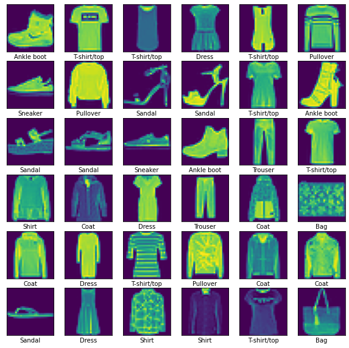

```python
class_names = ["T-shirt/top", "Trouser", "Pullover", "Dress", "Coat", "Sandal","Shirt", "Sneaker", "Bag", "Ankle boot"]

#Showing the first 36 images from training dataset on screen using plt function

plt.figure(figsize=(10,10))
for i in range(36):
    plt.subplot(6,6,i+1)
    plt.xticks([])
    plt.yticks([])
    plt.imshow(X_train_full_img[i])
    plt.xlabel(class_names[y_train_full[i]])
plt.show()
```

#### Write code for the dense layer

We now develop a feed-forward neural networks with the architecture $784 \rightarrow 20(ReLU) \rightarrow 25(ReLU) \rightarrow 10(softmax)$. We first declare the code for the hidden layer with a linear operation and activation. Since we are implementing using TF 1.x syntax, we first import the compatible version of TF 1.x in TF 2.x.

```python
import tensorflow.compat.v1 as tf
tf.disable_v2_behavior()
tf.compat.v1.set_random_seed(29143926)
```

[output not shown]

```python
import numpy as np

def dense_layer(x, num_neurons, name, activation=None):
# Allocating weights for dense layer by giving x as an input, b as bias with number of neurons and w is the init which is...
# calculated by truncated_normal module

    with tf.name_scope(name):
        num_inputs = int(x.get_shape()[1])
        stddev = 2 / np.sqrt(num_inputs)
        init = tf.truncated_normal([num_inputs, num_neurons], stddev=stddev)

        W = tf.Variable(init, name="W")
        b = tf.Variable(tf.truncated_normal([num_neurons], stddev=stddev))
        z = tf.matmul(x, W) + b

    #Sigmoid is the activation function which calculates the output from the value given using the formula
    if activation == "sigmoid":
        return tf.nn.sigmoid(z)

    #Sigmoid activation function returns the inputted value if possitive or zero if not positive
    elif activation == "relu":
        return tf.nn.relu(z)

    else:
        return z
```

#### Declare your network and visualize quantities of interest using TensorBoard

It is the time to implement your network with the architecture $784 \rightarrow 20(ReLU) \rightarrow 25(ReLU) \rightarrow 10(softmax)$. Note that we need to store and visualize the following quantities using TensorBoard:

- Gradients of trainable variables (weight matrices and biases) (Hint: use method `compute_gradients` with respect to the loss function).
- Hidden layers 1 and 2.

```python
num_hidden1 = 20
num_hidden2 = 25
num_outputs = 10
num_inputs = 784  #28 x 28
```

*Run the following cell to create necessary subfolders for this assignment. You must **not** modify these codes and **must** run it first*.

```python
# Create necessary subfolders to store immediate files for this assignment.

import os
if not os.path.exists("./models/dnn0"):
    os.makedirs("models/dnn0")
```

```python
inputs = tf.placeholder(tf.float32, shape=[None, num_inputs], name="inputs")
labels = tf.placeholder(tf.int32, shape=[None], name="labels")


with tf.name_scope("dnn"):

    #Going ahead with hidden layers which takes inputs and pass it to the next one after it goes through the activation function
    tf.compat.v1.set_random_seed(29143926)
    hidden1 = dense_layer(inputs, num_hidden1, name= "layer1", activation= "relu")
    hidden2 = dense_layer(hidden1, num_hidden2, name= "layer2", activation= "relu")
    logits = dense_layer(hidden2, num_outputs, name= "logits")

with tf.name_scope("loss"):

    #Counting the entropy and loss values
    xentropy = tf.nn.sparse_softmax_cross_entropy_with_logits(labels=labels, logits=logits, name='xentropy')

    loss = tf.reduce_mean(xentropy, name="loss")

with tf.name_scope("evaluation"):

    #Calculating the accuracy values using labels as given
    correct =  tf.nn.in_top_k(logits, labels, 1)
    accuracy = tf.reduce_mean(tf.cast(correct, tf.float32))

with tf.name_scope("train"):
    learning_rate = 0.001

    #Using Adam optimizer in this case to improve the performance of the model
    tf.compat.v1.set_random_seed(29143926)
    optimizer = tf.train.AdamOptimizer(learning_rate=0.001)
    grads = optimizer.compute_gradients(loss)
    training_op = optimizer.apply_gradients(grads)

    for var in tf.trainable_variables():
        tf.summary.histogram(var.op.name + "/values", var)

    for grad, var in grads:
        if grad is not None:
            tf.summary.histogram(var.op.name + "/gradients", grad)

#Summarising the overall accuracy of the model
accuracy_summary = tf.summary.scalar("accuracy", accuracy)
```

```python
# merge all summary
tf.summary.histogram('hidden1/activations', hidden1)
tf.summary.histogram('hidden2/activations', hidden2)
merged = tf.summary.merge_all()

init = tf.global_variables_initializer()

#Saving the trained model
saver = tf.train.Saver()

train_writer = tf.summary.FileWriter("models/dnn0/train", tf.get_default_graph())
test_writer = tf.summary.FileWriter("models/dnn0/test", tf.get_default_graph())

num_epochs = 50
batch_size = 128
```

#### Train your network and report the resutls, and inspect the computational graph and visualize the gradients, hidden layers 1,2

The **first** part of this sub-question requires you to write codes in the following cell.

```python
hist=[]
with tf.Session() as sess:
    init.run()
    print("Epoch\tTrain accuracy\tValid accuracy")

    #Getting the accuracy values epoch wise and resulting into final accuracy of train and validation dataset
    for epoch in range(num_epochs):
        for idx_start in range(0, X_train.shape[0], batch_size):

            idx_end = min(X_train.shape[0], idx_start + batch_size)
            X_batch, y_batch = X_train[idx_start:idx_end], y_train[idx_start:idx_end]

            sess.run(training_op, feed_dict={inputs: X_batch, labels: y_batch})


        summary_train, acc_train = sess.run([accuracy_summary, accuracy], feed_dict={inputs:X_train, labels:y_train}) #Insert your code here
        summary_valid, acc_valid = sess.run([accuracy_summary, accuracy], feed_dict={inputs:X_valid, labels:y_valid}) #Insert your code here


        train_writer.add_summary(summary_train, epoch)
        test_writer.add_summary(summary_valid, epoch)

        hist_item = {"hidden1":hidden1, "hidden2":hidden2, "weight1":merged, "weight2":loss, "weight3":accuracy}
        hist.append(hist_item)

        print("{}\t{}\t{}".format(epoch, acc_train, acc_valid))


    save_path = saver.save(sess, "models/dnn0.ckpt")
```

```
Epoch	Train accuracy	Valid accuracy
0	0.8352962732315063	0.8296666741371155
1	0.8541296124458313	0.8489999771118164
2	0.8648518323898315	0.8526666760444641
3	0.8707777857780457	0.8586666584014893
4	0.8751111030578613	0.862333357334137
5	0.8780555725097656	0.8628333210945129
6	0.882111132144928	0.8646666407585144
7	0.8847222328186035	0.8669999837875366
8	0.8861851692199707	0.8693333268165588
9	0.887333333492279	0.8683333396911621
10	0.8887592554092407	0.8673333525657654
11	0.8907777667045593	0.8661666512489319
12	0.8936481475830078	0.8681666851043701
13	0.8939259052276611	0.8700000047683716
14	0.8953518271446228	0.8711666464805603
15	0.8964444398880005	0.8703333139419556
16	0.8977592587471008	0.8705000281333923
17	0.8977222442626953	0.8706666827201843
18	0.89811110496521	0.8708333373069763
19	0.8987036943435669	0.8713333606719971
20	0.8989259004592896	0.8708333373069763
21	0.8990370631217957	0.8715000152587891
22	0.8989259004592896	0.871833324432373
23	0.898722231388092	0.8705000281333923
24	0.9002037048339844	0.871999979019165
25	0.9013888835906982	0.8711666464805603
26	0.9015740752220154	0.8713333606719971
27	0.9013333320617676	0.8693333268165588
28	0.9021296501159668	0.8698333501815796
29	0.9019073843955994	0.8691666722297668
30	0.9020000100135803	0.8686666488647461
31	0.9028703570365906	0.8681666851043701
32	0.9027777910232544	0.8668333292007446
33	0.9027592539787292	0.8679999709129333
34	0.9040555357933044	0.8668333292007446
35	0.9038703441619873	0.8679999709129333
36	0.9045185446739197	0.8681666851043701
37	0.9042037129402161	0.8671666383743286
38	0.9047222137451172	0.8683333396911621
39	0.9070370197296143	0.8671666383743286
40	0.9069259166717529	0.8694999814033508
41	0.9072222113609314	0.8681666851043701
42	0.9079629778862	0.8698333501815796
43	0.9077592492103577	0.8671666383743286
44	0.907370388507843	0.8675000071525574
45	0.9080740809440613	0.8688333630561829
46	0.9082037210464478	0.8668333292007446
47	0.9067962765693665	0.8668333292007446
48	0.9071851968765259	0.8671666383743286
49	0.9087036848068237	0.8688333630561829
```

The **second** part of this subquestion requires you use the Tensorboard, find out relevant visualizations and input them into the markdown cell below. (*Hint*: A software to capture the screen such as *Snipping Tools* in *Windows* may help).

**YOU ARE REQUIRED TO INSERT YOUR OWN GRAPHICS IN THIS MARKDOWN CELL**

- **Hidden activations**:

[output not shown]

- **Parameter gradients**:

[output not shown]

```python
import matplotlib.pyplot as plt
%matplotlib inline
plt.rcParams["figure.figsize"] = (8,10)
```

```python
def plot_hist(hist):
    hidden1 =[]
    hidden2=[]
    weight1=[]
    weight2=[]
    weight3=[]
    for h_item in history:
        train_losses.append(h_item["train_loss"])
        train_accuracies.append(h_item["train_acc"])
        valid_losses.append(h_item["val_loss"])
        valid_accuracies.append(h_item["val_acc"])
    plt.subplot(2,1,1)
    plt.plot(train_losses, "r.-", label="train loss")
    plt.plot(valid_losses, "b.-", label= "valid loss")
    plt.legend()
    plt.subplot(2,1,2)
    plt.plot(train_accuracies, "r.-", label="train acc")
    plt.plot(valid_accuracies, "b.-", label= "valid acc")
    plt.legend()

    plt.show()

plot_hist(hist)
```

[output not shown]

```python
#The output visualisations of the question can be found
#in the tensorflow visulisation site using (> tensorboard --logdir logs)
```